# Pitch, Hit, Profit: A Data-Backed Approach to Gaining an Edge in MLB Betting

Author

Andrew Cerqui, Jace Higa

Published

June 24, 2025

## 1 Data Summary

### 1.1 Data Ingestion

Our main data source was the **StatsAPI**, which provided MLB box score data in JSONL format. After uploading the raw files to Railway and our Postgres database, we had to figure out how to parse the nested JSON using SQL. This process involved trial and error until we found queries that matched our table structure. Scraping setup took time as we explored different sources before settling on an API that supported our needs. Once we finalized our approach, the ingestion process was fairly smooth, mainly focused on correctly inserting parsed JSONL into our schema.

The second data source was **Statcast data from Baseball Savant**, provided as CSV files. We cleaned these by deleting irrelevant columns, renaming headers, and standardizing the format to match our database requirements. Uploading from the terminal into our PostgreSQL database went smoothly, resulting in well-structured and usable tables.

Most of the challenges we encountered involved experimentation rather than critical issues.

### 1.2 Data Organization

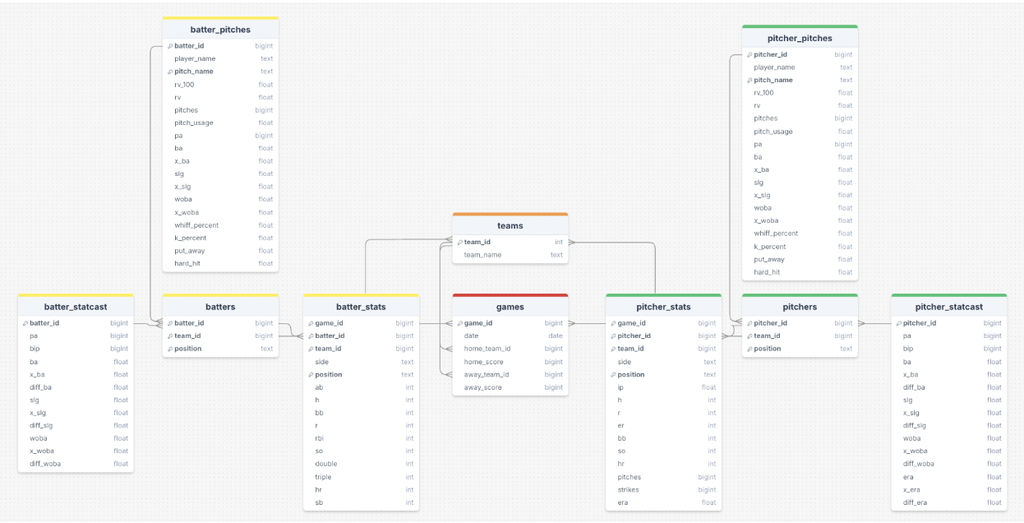

Entity Relationship Diagram of MLB Data Schema

This is what our Entity Relationship Diagram looks like. The main table stems from `games`, which connects to many other tables. The `teams` table adds context by joining via `team_id`, allowing us to analyze team-level data.

From `batter_stats` and `pitcher_stats`, we can access game context using `game_id`, and then retrieve player-specific details through the `batters` and `pitchers` tables. These two tables are keyed on `batter_id`, `pitcher_id`, `team_id`, and `position` or `type`, which lets us track players who change positions (or teams) throughout the season.

For example, **Cal Raleigh** is primarily a catcher. Over 227 at-bats in that role, he has a .295 average and 1.136 OPS—MVP-caliber numbers. As a DH over 67 at-bats, however, he has just a .194 average and .659 OPS. That kind of role-based discrepancy highlights why tracking **positional splits** is important.

Finally, we have Statcast data: `batter_statcast` and `pitcher_statcast`, along with `batter_pitches` and `pitcher_pitches`. These contain advanced metrics, including expected stats and run values per pitch, and are joined via player IDs.

### 1.3 Data Compilation

#### 1.3.1 Figure 1

This is an example of a table that we created to take a look at all players from the different teams that have played **shortstop (SS)**. We used the `teams` table to extract the **team_name**, the `batters` table to find players who have logged game time at **shortstop**, and the `batter_pitches` table to get the **player_name** of the batters. We chose that table because the name of the players was in a nicer format on **Statcast** than they were in the **box scores** data we pulled.

```sql
-- Players Who Have Played SS Across Each Team --
SELECT DISTINCT
  t3.player_name,
  t1.team_name,
  t2.position
FROM teams AS t1
JOIN batters AS t2 ON t1.team_id = t2.team_id
JOIN batter_pitches AS t3 ON t2.batter_id = t3.batter_id
WHERE t2.position = 'SS'
ORDER BY t1.team_name, t3.player_name;
```

| player_name | team_name | position |
| --- | --- | --- |
| Perdomo, Geraldo | ARI | SS |
| Allen, Nick | ATL | SS |
| Henderson, Gunnar | BAL | SS |
| Story, Trevor | BOS | SS |
| Hoerner, Nico | CHC | SS |
| Swanson, Dansby | CHC | SS |
| De La Cruz, Elly | CIN | SS |
| Arias, Gabriel | CLE | SS |
| Schneemann, Daniel | CLE | SS |
| Meidroth, Chase | CWS | SS |
| Báez, Javier | DET | SS |
| Sweeney, Trey | DET | SS |
| Dubón, Mauricio | HOU | SS |
| Peña, Jeremy | HOU | SS |
| Witt Jr., Bobby | KC | SS |
| Neto, Zach | LAA | SS |
| Betts, Mookie | LAD | SS |
| Rojas, Miguel | LAD | SS |
| Lopez, Otto | MIA | SS |
| Ortiz, Joey | MIL | SS |
| Correa, Carlos | MIN | SS |
| Lee, Brooks | MIN | SS |
| Lindor, Francisco | NYM | SS |
| Peraza, Oswald | NYY | SS |
| Volpe, Anthony | NYY | SS |
| Wilson, Jacob | OAK | SS |
| Turner, Trea | PHI | SS |
| Kiner-Falefa, Isiah | PIT | SS |
| Bogaerts, Xander | SD | SS |
| Iglesias, Jose | SD | SS |
| Crawford, J.P. | SEA | SS |
| Adames, Willy | SF | SS |
| Winn, Masyn | STL | SS |
| Caballero, José | TB | SS |
| Walls, Taylor | TB | SS |
| Seager, Corey | TEX | SS |
| Bichette, Bo | TOR | SS |
| Giménez, Andrés | TOR | SS |
| Abrams, CJ | WSH | SS |

#### 1.3.2 Figure 2

With this table we found the highest **rv** or **run values** for individual **pitch types**. It just basically means which batters hit certain pitches the best, so **Aaron Judge** has the highest run value overall against a single pitch—and that happens to be the **4-Seam Fastball**.

We used the `batter_pitches` table to get the **player_name** again, the `teams` table to get the **team_name** they are from, and had to use the `batters` table to get the **position** through a **common table expression (CTE)**. We used the CTE to determine the player’s most frequently played **position**, since it makes the most sense to list the most common position they play. Then we used the `batter_pitches` table again to get the **rv** values for the various **pitch_name** types. Together it gave us the table pictured to the left.

```sql
-- Top 10 Highest Run Values Against Different Pitches --
WITH most_common_positions AS (
  SELECT
    batter_id,
    position,
    COUNT(*) AS position_count,
    ROW_NUMBER() OVER (PARTITION BY batter_id ORDER BY COUNT(*) DESC) AS row_num
  FROM batter_stats
  GROUP BY batter_id, position
),
ranked_pitches AS (
  SELECT
    t3.player_name,
    t1.team_name,
    t4.position,
    t3.pitch_name,
    t3.rv,
    ROW_NUMBER() OVER (PARTITION BY t3.batter_id ORDER BY t3.rv DESC) AS row
  FROM batter_pitches AS t3
  JOIN batters AS t2 ON t3.batter_id = t2.batter_id
  JOIN teams AS t1 ON t2.team_id = t1.team_id
  JOIN most_common_positions AS t4
    ON t3.batter_id = t4.batter_id
  WHERE t4.row_num = 1
)
SELECT
  player_name,
  team_name,
  position,
  pitch_name,
  rv
FROM ranked_pitches
WHERE row = 1
ORDER BY rv DESC
LIMIT 10;
```

| player_name | team_name | position | pitch_name | rv |
| --- | --- | --- | --- | --- |
| Judge, Aaron | NYY | RF | 4-Seam Fastball | 17 |
| Schwarber, Kyle | PHI | DH | 4-Seam Fastball | 13 |
| Tucker, Kyle | CHC | RF | 4-Seam Fastball | 12 |
| Guerrero Jr., Vladimir | TOR | 1B | 4-Seam Fastball | 12 |
| Wilson, Jacob | OAK | SS | Slider | 11 |
| Ramírez, José | CLE | 3B | Sinker | 11 |
| Díaz, Yandy | TB | DH | 4-Seam Fastball | 11 |
| Castro, Willi | MIN | 2B | 4-Seam Fastball | 10 |
| Alonso, Pete | NYM | 1B | Sinker | 10 |
| Marte, Ketel | ARI | 2B | 4-Seam Fastball | 10 |

#### 1.3.3 Figure 3

This table displays the pitchers with the highest **diff_era**. It basically shows which pitcher has had the worst luck, since **diff_era** is calculated by **ERA - xERA**. So, it’s a measure of how high their actual earned run average is in comparison to what it is expected to be.

To create this table, we used the `pitchers` table to get the **position**, the `teams` table to get **team_name**, the `pitcher_pitches` table to get the **player_name** in a nice format, and the `pitcher_statcast` table to get the **diff_era** stat that this analysis is based on.

```sql
-- Highest diff_era, Pitchers Who Have Been Unlucky --
WITH ranked_pitchers AS (
  SELECT
    t1.pitcher_id,
    t3.player_name,
    t1.position,
    t2.team_name,
    t4.diff_era,
    ROW_NUMBER() OVER (PARTITION BY t1.pitcher_id ORDER BY t4.diff_era DESC) AS row
  FROM pitchers AS t1
  JOIN teams AS t2 ON t1.team_id = t2.team_id
  JOIN pitcher_pitches AS t3 ON t1.pitcher_id = t3.pitcher_id
  JOIN pitcher_statcast AS t4 ON t1.pitcher_id = t4.pitcher_id
  WHERE t3.pitches > 150
)
SELECT
  player_name,
  position,
  team_name,
  diff_era
FROM ranked_pitchers
WHERE row = 1
ORDER BY diff_era DESC
LIMIT 10;
```

| player_name | position | team_name | diff_era |
| --- | --- | --- | --- |
| Alcala, Jorge | RP | BOS | 4.007 |
| Kinley, Tyler | RP | COL | 3.187 |
| Romano, Jordan | RP | PHI | 2.689 |
| Ferguson, Tyler | RP | OAK | 2.506 |
| Fluharty, Mason | RP | TOR | 2.043 |
| Alcantara, Sandy | SP | MIA | 1.999 |
| Ferrer, Jose A. | RP | WSH | 1.898 |
| Soroka, Michael | SP | WSH | 1.883 |
| Miller, Mason | RP | OAK | 1.834 |
| Rodriguez, Eduardo | SP | ARI | 1.700 |